Zadanie 1. W tym zadaniu porównamy techniki LASSO oraz regresji grzbietowej z kryteriami informacyjnymi (AIC, BIC) w przypadku regresji liniowej.

Naszym celem jest zbadanie, jak dobrze każda z tych technik oddaje prawdziwy model oraz jak dobrze nadaje się do predykcji. Metoda LASSO została omówiona na Wykładzie 10. Więcej informacji na jej temat można przeczytać m.in. tutaj, a obejrzeć tutaj (ten tutorial dotyczy regresji logistycznej, ale myślę, że na tym etapie domyślicie się już, jak to się ma do regresji liniowej). Jedną z największych zalet metody LASSO, poza tym, że umożliwia całkiem skuteczny wybór modelu, jest to, że można ją stosować do danych w których mamy więcej cech niż obserwacji.

```r
B <- c(crim=1.52274943515658, zn=-2.79081122064963, indus=0,
       nox=1.4332089680247, rm=1.03212527744472, age=0,
       dis=2.75923800934106, tax=2.43884606240317, ptratio=0,
       black=-0.371096117421985, lstat=1.09251574007794, medv=0)
```

- Załaduj dane Boston z pakietu MASS. Sprawdź w dokumentacji typy zmiennych. Jakiego typu może być zmienna ‘rad’?
- Usuń zmienne jakościowe. Powinno pozostać 12 zmiennych ilościowych.
- Przeskaluj dane za pomocą funkcji scale. Jakiego typu jest wynik? Skonwertuj go z powrotem do data.frame. ### Usuwamy zmienne jakościowe i skalujemy

```r
library(MASS)
data(Boston)
head(Boston)
```

```
##      crim zn indus chas   nox    rm  age    dis rad tax ptratio  black lstat
## 1 0.00632 18  2.31    0 0.538 6.575 65.2 4.0900   1 296    15.3 396.90  4.98
## 2 0.02731  0  7.07    0 0.469 6.421 78.9 4.9671   2 242    17.8 396.90  9.14
## 3 0.02729  0  7.07    0 0.469 7.185 61.1 4.9671   2 242    17.8 392.83  4.03
## 4 0.03237  0  2.18    0 0.458 6.998 45.8 6.0622   3 222    18.7 394.63  2.94
## 5 0.06905  0  2.18    0 0.458 7.147 54.2 6.0622   3 222    18.7 396.90  5.33
## 6 0.02985  0  2.18    0 0.458 6.430 58.7 6.0622   3 222    18.7 394.12  5.21
##   medv
## 1 24.0
## 2 21.6
## 3 34.7
## 4 33.4
## 5 36.2
## 6 28.7
```

```r
x_vars <- as.matrix(Boston[, -c(4, 9)])
x_vars <- scale(x_vars)
x_vars <- data.frame(x_vars)
head(x_vars)
```

```
##         crim         zn      indus        nox        rm        age      dis
## 1 -0.4193669  0.2845483 -1.2866362 -0.1440749 0.4132629 -0.1198948 0.140075
## 2 -0.4169267 -0.4872402 -0.5927944 -0.7395304 0.1940824  0.3668034 0.556609
## 3 -0.4169290 -0.4872402 -0.5927944 -0.7395304 1.2814456 -0.2655490 0.556609
## 4 -0.4163384 -0.4872402 -1.3055857 -0.8344581 1.0152978 -0.8090878 1.076671
## 5 -0.4120741 -0.4872402 -1.3055857 -0.8344581 1.2273620 -0.5106743 1.076671
## 6 -0.4166314 -0.4872402 -1.3055857 -0.8344581 0.2068916 -0.3508100 1.076671
##          tax    ptratio     black      lstat       medv
## 1 -0.6659492 -1.4575580 0.4406159 -1.0744990  0.1595278
## 2 -0.9863534 -0.3027945 0.4406159 -0.4919525 -0.1014239
## 3 -0.9863534 -0.3027945 0.3960351 -1.2075324  1.3229375
## 4 -1.1050216  0.1129203 0.4157514 -1.3601708  1.1815886
## 5 -1.1050216  0.1129203 0.4406159 -1.0254866  1.4860323
## 6 -1.1050216  0.1129203 0.4101651 -1.0422909  0.6705582
```

### Wybieramy zbiór treningowy

Żeby ocenić poszczególne metody, w pierwszym kroku podziel dane na zbiór treningowy rozmiaru 60 oraz zbiór testowy złożony z pozostałych obserwacji. Jeśli masz ochotę zrobić to porządniej, to możesz przeprowadzić walidację krzyżową, ale w tym zadaniu nie jest to obowiązkowe.

```r
train_set <- sample(1:nrow(x_vars), 60, rep=F)
X_train <- x_vars[train_set, ]
X_test <- x_vars[-train_set, ]
```

```r
head(x_vars)
```

```
##         crim         zn      indus        nox        rm        age      dis
## 1 -0.4193669  0.2845483 -1.2866362 -0.1440749 0.4132629 -0.1198948 0.140075
## 2 -0.4169267 -0.4872402 -0.5927944 -0.7395304 0.1940824  0.3668034 0.556609
## 3 -0.4169290 -0.4872402 -0.5927944 -0.7395304 1.2814456 -0.2655490 0.556609
## 4 -0.4163384 -0.4872402 -1.3055857 -0.8344581 1.0152978 -0.8090878 1.076671
## 5 -0.4120741 -0.4872402 -1.3055857 -0.8344581 1.2273620 -0.5106743 1.076671
## 6 -0.4166314 -0.4872402 -1.3055857 -0.8344581 0.2068916 -0.3508100 1.076671
##          tax    ptratio     black      lstat       medv
## 1 -0.6659492 -1.4575580 0.4406159 -1.0744990  0.1595278
## 2 -0.9863534 -0.3027945 0.4406159 -0.4919525 -0.1014239
## 3 -0.9863534 -0.3027945 0.3960351 -1.2075324  1.3229375
## 4 -1.1050216  0.1129203 0.4157514 -1.3601708  1.1815886
## 5 -1.1050216  0.1129203 0.4406159 -1.0254866  1.4860323
## 6 -1.1050216  0.1129203 0.4101651 -1.0422909  0.6705582
```

- Utwórz wektor prawdziwych parametrów $\beta$, na przykład losując 12 obserwacji z rozkładu $Unif(-3, 3)$

```r
B <- c(crim=1.52274943515658, zn=-2.79081122064963, indus=0,
       nox=1.4332089680247, rm=1.03212527744472, age=0,
       dis=2.75923800934106, tax=2.43884606240317, ptratio=0,
       black=-0.371096117421985, lstat=1.09251574007794, medv=0)
# wykorzystuje zmienną prowadzącego

zeroB <- sample(c(T, F), 12, rep=T) #wybieramy ze zwracaniem T lub F
B[zeroB] <- 0
names(B) <- names(x_vars)
head(B)
```

```
##      crim        zn     indus       nox        rm       age
##  1.522749 -2.790811  0.000000  0.000000  0.000000  0.000000
```

```r
Y <- as.matrix(x_vars) %*% B + rnorm(nrow(Boston), 0, 1)
Y_train <- Y[train_set]
Y_test <- Y[-train_set]
```

### 1. Zwykły model liniowy.

Stwórz model liniowy za pomocą `lm`. Czy model poprawnie wykrył, od których zmiennych zależy `Y`? Porównaj wartości estymatorów
$$β_j$$
z prawdziwymi wartościami
$$β_j$$
. Zbadaj błąd średniokwadratowy predykcji na zbiorze testowym (pamiętaj, że znasz prawdziwe wartości zmiennej Y na zbiorze testowym). Porównaj go z minimalnym błędem jaki możemy otrzymać, czyli Yi−Xiβ.

```r
lm_model <- lm(Y_train~., X_train) # zwykły model linowy
summary(lm_model)
```

```
##
## Call:
## lm(formula = Y_train ~ ., data = X_train)
##
## Residuals:
##      Min       1Q   Median       3Q      Max
## -2.56332 -0.66372  0.03448  0.63066  2.18034
##
## Coefficients:
##             Estimate Std. Error t value Pr(>|t|)
## (Intercept) -0.19696    0.16855  -1.169    0.248
## crim         1.23719    0.52649   2.350    0.023 *
## zn          -2.67501    0.24115 -11.093 1.01e-14 ***
## indus        0.06661    0.30484   0.219    0.828
## nox         -0.11825    0.32466  -0.364    0.717
## rm          -0.18395    0.29850  -0.616    0.541
## age         -0.14826    0.27066  -0.548    0.586
## dis          2.54131    0.27708   9.172 4.83e-12 ***
## tax          0.18667    0.34237   0.545    0.588
## ptratio      0.05436    0.24533   0.222    0.826
## black       -0.12605    0.18519  -0.681    0.499
## lstat        0.27218    0.36916   0.737    0.465
## medv         0.15104    0.30743   0.491    0.626
## ---
## Signif. codes:  0 '***' 0.001 '**' 0.01 '*' 0.05 '.' 0.1 ' ' 1
##
## Residual standard error: 1.186 on 47 degrees of freedom
## Multiple R-squared:  0.8283, Adjusted R-squared:  0.7844
## F-statistic: 18.89 on 12 and 47 DF,  p-value: 4.594e-14
```

```r
Y_test_hat <- predict(lm_model, X_test)
train_error <- mean(lm_model$residuals^2)
test_error <- mean((Y_test - Y_test_hat)^2)
train_error; test_error;
```

```
## [1] 1.101938
```

```
## [1] 1.15529
```

### 2. Kryterium informacyjne:

```r
aic_model <- stepAIC(lm_model, trace=F)
bic_model <- stepAIC(lm_model, k=log(nrow(X_train)), trace=F)

cbind('True'= c(0, B), 'AIC'=aic_model$coefficients, 'LM'=lm_model$coefficients)
```

```
##               True        AIC          LM
##          0.0000000 -0.1195639 -0.19695963
## crim     1.5227494  1.7497512  1.23718896
## zn      -2.7908112 -2.7977265 -2.67500709
## indus    0.0000000  2.6072528  0.06661138
## nox      0.0000000 -0.1195639 -0.11825399
## rm       0.0000000  1.7497512 -0.18394988
## age      0.0000000 -2.7977265 -0.14826409
## dis      2.7592380  2.6072528  2.54131373
## tax      0.0000000 -0.1195639  0.18666528
## ptratio  0.0000000  1.7497512  0.05435942
## black   -0.3710961 -2.7977265 -0.12605384
## lstat    0.0000000  2.6072528  0.27217865
## medv     0.0000000 -0.1195639  0.15104087
```

```r
aic_train <- mean(aic_model$residuals^{2})
aic_test <- mean(Y_test - predict(bic_model, X_test))
aic_train; aic_test
```

```
## [1] 1.194774
```

```
## [1] 0.1644185
```

Błędy predykcji dla kryterium BIC

```r
bic_train <- mean(bic_model$residuals^{2})
bic_test <- mean((Y_test - predict(bic_model, X_test))^{2})
bic_train; bic_test;
```

```
## [1] 1.194774
```

```
## [1] 1.217957
```

- [X] Porównaj kryterium AIC z kryterium BIC.
- [X] To ostatnie, zgodnie z teorią, prowadzi do wyboru poprawnego modelu, o ile możemy porównać ze sobą wszystkie potencjalne modele (zamiast wykorzystywać strategię krokową) oraz posiadamy nieskończenie wiele obserwacji.
3. Regresja LASSO.
- [X] Dopasuj model LASSO do zbioru treningowego za pomocą funkcji cv.glmnet z biblioteki glmnet.
- [X] Funkcja ta sama wybierze pewną liczbę wartości $λ$ do przetestowania, i dla każdej z nich przeprowadzi walidację krzyżową aby ocenić błąd predykcji.
- [X] Ponieważ nasze dane są już wystandaryzowane, ustaw w funkcji cv.glmnet atrybut standardize=F; ponadto ustaw thresh=1e-16 aby otrzymać dokładniejszą estymację.
- [X] Uwaga: funkcja cv.glmnet i inne funkcje z tego pakietu wymagają na wejściu macierzy, a nie ramki danych - należy wykorzystać funkcję as.matrix().

```r
library(glmnet)
```

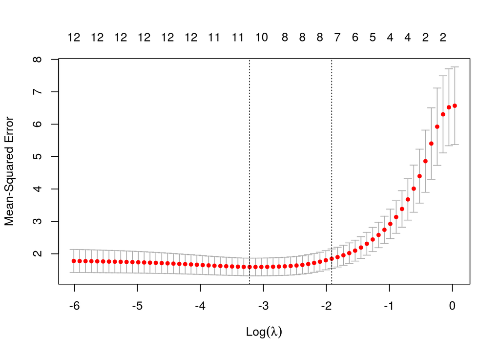

```r
X_train <- as.matrix(X_train)
X_test <- as.matrix(X_test)

simple.cv <- cv.glmnet(X_train, Y_train, standardize=F, intercept=T, thresh=1e-16)
plot(simple.cv)
```

```r
coef <- coef(simple.cv)
coef
```

```
## 13 x 1 sparse Matrix of class "dgCMatrix"
##                       1
## (Intercept) -0.26720001
## crim         0.29028964
## zn          -2.18576644
## indus        .
## nox          .
## rm          -0.18116798
## age          .
## dis          2.02684757
## tax          0.26132059
## ptratio      0.09197823
## black       -0.00583428
## lstat        0.10871796
## medv         .
```

```r
# Porównanie metod:
cbind('True'= c(0, B), 'LASSO'=coef, 'LM'=lm_model$coefficients)
```

```
## 13 x 3 sparse Matrix of class "dgCMatrix"
##                   True           1          LM
## (Intercept)  .         -0.26720001 -0.19695963
## crim         1.5227494  0.29028964  1.23718896
## zn          -2.7908112 -2.18576644 -2.67500709
## indus        .          .           0.06661138
## nox          .          .          -0.11825399
## rm           .         -0.18116798 -0.18394988
## age          .          .          -0.14826409
## dis          2.7592380  2.02684757  2.54131373
## tax          .          0.26132059  0.18666528
## ptratio      .          0.09197823  0.05435942
## black       -0.3710961 -0.00583428 -0.12605384
## lstat        .          0.10871796  0.27217865
## medv         .          .           0.15104087
```

```r
final_model <- lm(Y_train ~ crim + zn + nox + age + dis + tax + lstat, data= as.data.frame(X_train))
final_pred <- predict(final_model, as.data.frame(X_test))
final_error <- mean((Y_test - final_pred)^2)
```

- [X] Porównaj błąd na zbiorze testowym wybranym na początku tego zadania.
- [X] Może być on większy niż w przypadku innych technik, ponieważ metoda LASSO może wprowadzić spore obciążenie do estymowanych parametrów - w następnym zadaniu zobaczymy, jak to poprawić.

```r
final_error;test_error
```

```
## [1] 1.21984
```

```
## [1] 1.15529
```